# Modelling the distribution of potential primary forests in the Carpathians

Francesco Maria Sabatini

27 8 2024

[figure not shown]

Primary forests have high conservation value but are rare in Europe due to historic land use. Yet many primary forest patches remain unmapped, especially in the Carpathians, which are the stronghold of primary forests in Europe. Based on data contained in the [European Primary Forest Database v2.0](https://figshare.com/articles/dataset/European_Primary_Forest_Database/13194095) [(Sabatini et al. 2021 - DDI)](https://www.nature.com/articles/s41597-021-00988-7), we will train a model to predict where still-to-be-mapped primary forests are likely to be located in the Carpathians. As predictors, we will use a selection of variables related to topography, climate and land-use. Our model will be generated using an approach derived from Species Distribution Modelling (SDM), which relies on the use of a Machine-Learning algorithm - Boosted Regression Trees (BRTs). This is a powerful algorithm which requires little or no assumptions, and can flexibly model non-linear relationships and multi-level interactions. BRTs rely on regression trees, which partition the predictor space into rectangles, using a series of rules to identify regions having the most homogeneous responses to predictors, and then fit a constant to each region. The main difference is that BRTs do not produce a single ‘best’ model. Rather, they use the technique of boosting to combine large numbers of relatively simple tree models adaptively, to minimize the unexplained variation by adding, at each step, a new tree which maximally reduces the residuals.

For a guide to BRTs see [Elith et al. (2008)](https://besjournals.onlinelibrary.wiley.com/doi/10.1111/j.1365-2656.2008.01390.x) and the [vignette of the Dismo package](https://rspatial.org/raster/sdm/).

Goals of this exercise:  
1. Get familiar with the manipulation of spatial data in R  
2. Create a model predicting the likelihood of occurrence of primary forests stands in the Carpathians using BRTs  
3. Validate the model and explore the output  
4. Discuss the output & the limitations of the approach

All data and code is available at the link:  
https://cloud.idiv.de/nextcloud/index.php/s/CGTCGWBXFj59fsz

## Install and load packages

Make sure you have all the packages installed, first.

```r
# install.packages(c("tidyverse", "raster", "st", "rgdal", "gbm", "dismo", "blockCV", "automap", "cowplot", "rgeos")) if necessary
library(tidyverse)
library(sf)
library(terra)

#library(rgeos)
```

## Prepare geographical data

Import and visualize spatial predictors. Convert to WGS84

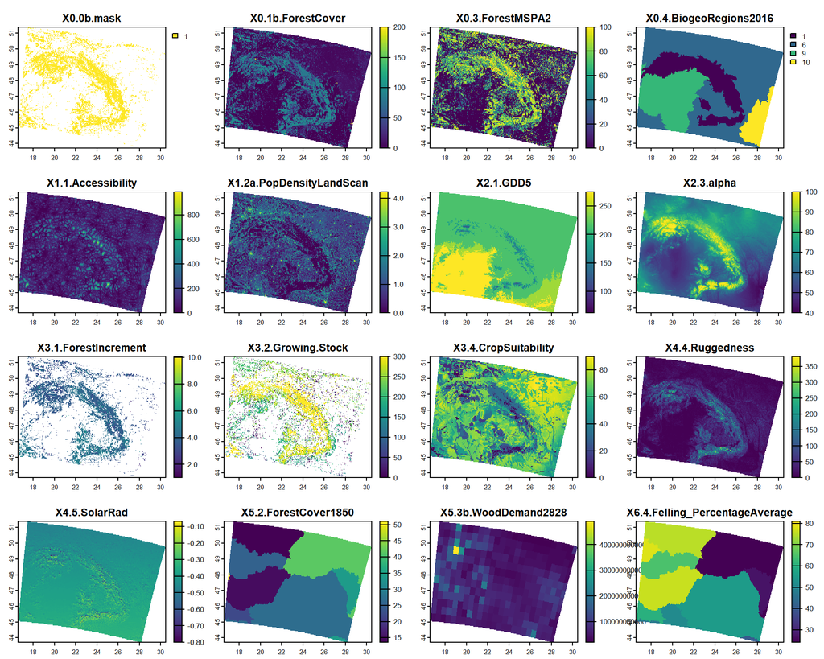

```r
files <- list.files(path="../_data", pattern="*.tif$", full.names = T)
mystack <- rast(files)
mystack <- project(mystack, y="epsg:4326", method = "near")
plot(mystack)
```

A description of the predictors, with the related sources, is in Table 1 from [Sabatini et al. 2018](https://onlinelibrary.wiley.com/doi/full/10.1111/ddi.12778).

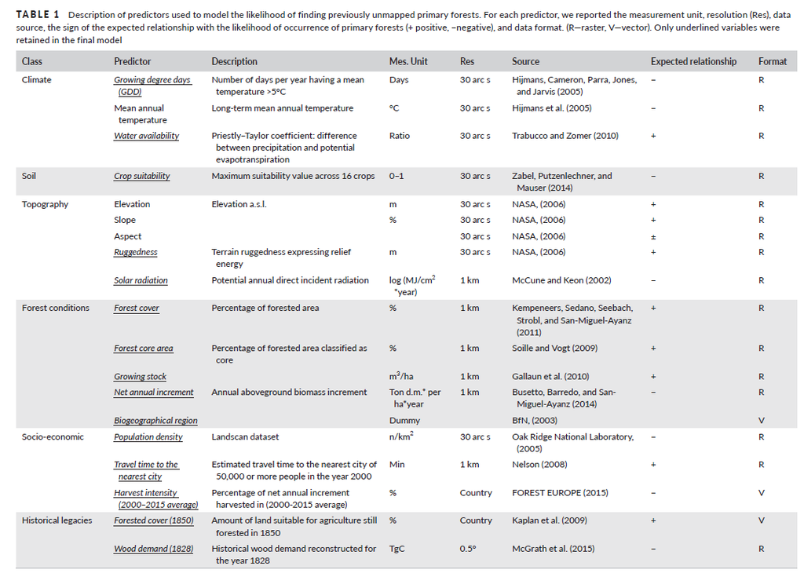

Import data on primary forests

```r
primary.all <- read_sf("../_data/EPFD_primaryForest_OA.shp")
#visualize data
primary.all
```

```
## Simple feature collection with 18411 features and 29 fields
## Geometry type: MULTIPOLYGON
## Dimension:     XY
## Bounding box:  xmin: -17.30734 ymin: 28.10636 xmax: 62.39311 ymax: 71.00632
## Geodetic CRS:  WGS 84
## # A tibble: 18,411 × 30
##    OBJEC FOREST_N LOCAT NATUR DOMINANT_T DOMINANT_1 DOMINANT_2 THREAT_1 THREAT_2
##    <int> <chr>    <chr> <int> <chr>      <chr>      <chr>         <int>    <int>
##  1     1 "Riaba …  <NA>     0 <NA>       <NA>       <NA>             NA       NA
##  2     2 "Stu\u0…  <NA>     0 <NA>       <NA>       <NA>             NA       NA
##  3     3 "Uzhans… "Tra…     6 Fagus syl… <NA>       <NA>             NA       NA
##  4     4 "Uzhans… "Tra…     6 Fagus syl… <NA>       <NA>             NA       NA
##  5     5 "Uzhans… "Tra…     6 Fagus syl… <NA>       <NA>             NA       NA
##  6     6 "Uzhans… "Tra…     6 Fagus syl… <NA>       <NA>             NA       NA
##  7     7 "Uzhans… "Tra…     6 Fagus syl… <NA>       <NA>             NA       NA
##  8     8 "Uzhans… "Tra…     6 Fagus syl… <NA>       <NA>             NA       NA
##  9     9 "Uzhans… "Tra…     6 Fagus syl… <NA>       <NA>             NA       NA
## 10    10 "Plajsk… "Syw…     6 Picea abi… Pinus cem… <NA>             NA       NA
## # ℹ 18,401 more rows
## # ℹ 21 more variables: LAST_DISTU <chr>, LAST_DIS_1 <int>, LAST_DIS_2 <int>,
## #   LAST_DIS_3 <chr>, LAST_DIS_4 <int>, LAST_DIS_5 <int>, PROTECTI <int>,
## #   PROTECTE <int>, RELEV <chr>, CONTA <chr>, Notes <chr>, ID_Dt <chr>,
## #   Sourc <chr>, Are_h <dbl>, SHAPE_L <dbl>, SHAPE_A <dbl>, FOREST_TYP <int>,
## #   FOREST_T_1 <int>, BIOGE <chr>, FOREST_S <dbl>, geometry <MULTIPOLYGON [°]>
```

```r
#filter out all unnecessary fields
primary.sf <- primary.all %>%
  mutate(is.primary=1) %>%
  dplyr::select(is.primary) %>%
  st_make_valid() #Fixes some topological errors in the input shp
#Drop remaining invalid polygons (n=3)
primary.sf <- primary.sf %>%
  slice(which(st_is_valid(primary.sf)))
```

Import AOI (area of interest) - Polygon of the Carpathians Mountain Range. Convert it to WGS84 to ensure compatibility with the data in the EPFD v2.0.

```r
carpathians.sf <- read_sf("../_data/EuropeanMountainAreas/m_massifs_v1.shp") %>%
  filter(name_mm == "Carpathians") %>%
  st_transform(crs(primary.sf)) %>%
  st_make_valid()
```

Select only primary forests inside the Carpathians and visualize

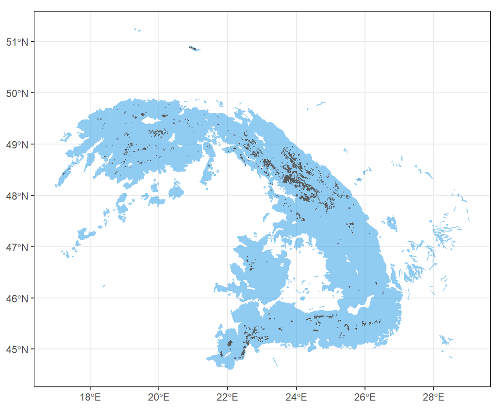

```r
contained <- st_contains(carpathians.sf, primary.sf)
primary.carp <- primary.sf[unique(unlist(contained)),]

#visualize
ggplot()  +
  geom_sf(data=carpathians.sf, col=NA, fill=4, alpha=0.5) +
  geom_sf(data=primary.carp) +
  theme_bw()
```

Rasterize `primary.carp` and add to stack of predictors

```r
primary.raster <- rasterize(primary.carp, mystack)
mystack <- c(primary.raster, mystack)
names(mystack)[1] <- "Y.Primary.forest"
```

## Model distribution of primary forests

To train our BRT, we need to export the data from our raster stack into a data.frame. We also need to mask out all pixels which are not forests.

```r
mydata0 <- values(mystack) %>%
  as_tibble()
mydata.coord <- crds(mystack, na.rm=F) %>%
  as_tibble()
mydata <- mydata.coord %>%
  bind_cols(mydata0) %>%
  ### mask only forested pixels. Exclude pixels with NA in GS
  filter(!is.na(X0.0b.mask) & !is.na(X3.2.Growing.Stock)) %>%
  ## Define all remaining forest pixels to NON-primary if NA
  mutate(Y.Primary.forest=ifelse(!is.na(Y.Primary.forest), 1, 0)) %>%
  ### define biogeoregions as a factors
  mutate(X0.4.BiogeoRegions2016 = factor(X0.4.BiogeoRegions2016))

#visualize
glimpse(mydata)
```

```
## Rows: 116,233
## Columns: 19
## $ x                              <dbl> 17.50851, 17.51978, 17.50851, 17.51978,…
## $ y                              <dbl> 51.39235, 51.39235, 51.38107, 51.38107,…
## $ Y.Primary.forest               <dbl> 0, 0, 0, 0, 0, 0, 0, 0, 0, 0, 0, 0, 0, …
## $ X0.0b.mask                     <dbl> 1, 1, 1, 1, 1, 1, 1, 1, 1, 1, 1, 1, 1, …
## $ X0.1b.ForestCover              <dbl> 88, 97, 99, 94, 94, 95, 95, 76, 76, 73,…
## $ X0.3.ForestMSPA2               <dbl> 76, 92, 94, 87, 88, 90, 90, 81, 81, 81,…
## $ X0.4.BiogeoRegions2016         <fct> 6, 6, 6, 6, 6, 6, 6, 6, 6, 6, 6, 6, 6, …
## $ X1.1.Accessibility             <dbl> 53, 52, 37, 35, 33, 52, 52, 33, 33, 33,…
## $ X1.2a.PopDensityLandScan       <dbl> 0.6989700, 0.3010300, 0.3010300, 0.3010…
## $ X2.1.GDD5                      <dbl> 214, 214, 214, 214, 214, 214, 214, 214,…
## $ X2.3.alpha                     <dbl> 62, 62, 62, 62, 63, 64, 64, 63, 63, 64,…
## $ X3.1.ForestIncrement           <dbl> 3.157283, 4.446121, 5.022512, 4.770824,…
## $ X3.2.Growing.Stock             <dbl> 218, 235, 236, 210, 212, 226, 226, 226,…
## $ X3.4.CropSuitability           <dbl> 28, 28, 28, 28, 28, 28, 28, 10, 10, 28,…
## $ X4.4.Ruggedness                <dbl> 8.375, 7.750, 12.250, 10.625, 8.750, 11…
## $ X4.5.SolarRad                  <dbl> -0.4842463, -0.4844772, -0.4968904, -0.…
## $ X5.2.ForestCover1850           <dbl> 13.504, 13.504, 13.504, 13.504, 13.504,…
## $ X5.3b.WoodDemand2828           <dbl> 50488336384, 50488336384, 50488336384, …
## $ X6.4.Felling_PercentageAverage <dbl> 75, 75, 75, 75, 75, 75, 75, 75, 75, 75,…
```

### Naïve model

We fit a preliminary model. We call it naïve because we are not accounting for the extremely clutered distribution of our primary forest pixel, which might give rise to issues of autocorrelation. Take ten times as many background points as presence points. Split in k=5 folds, four to be used as training, one as test dataset.

```r
library(gbm)
library(dismo)
```

```r
set.seed(2908)
#count num of PF pixels
n.pf <- nrow(mydata %>% filter(Y.Primary.forest==1))
mysize  <- 0.5 ## reduce sample size to increase speed of model

mysample.naive <- mydata %>%
  #define sample.size
  #set sample size for pixels to be randomly drawn.
  #We keep all primary forests, and sample 10 times as many background points
  mutate(sample.size=ifelse(Y.Primary.forest==1, n.pf*mysize, 10*n.pf*mysize)) %>%
  group_by(Y.Primary.forest) %>%
  sample_n(size = first(sample.size)) %>%
  ungroup() %>%
  # split in k=5 folds
  mutate(kfold=kfold(Y.Primary.forest, k=5)) %>%
  as.data.frame()
```

We will fit the model only on 80% of the data selected. The remaining 20% we keep for testing the goodness of our model

```r
train.data <- mysample.naive %>%
  filter(kfold != 5)
test.data <- mysample.naive %>%
  filter(kfold == 5)

#### run BRTs and explore output
brt.naive <- gbm.step(data=train.data,
                      gbm.x = 5:19, gbm.y = "Y.Primary.forest",
                      family = "bernoulli", tree.complexity = 5,
                      learning.rate = 0.05, bag.fraction = 0.5)
```

```
##
##
##  GBM STEP - version 2.9
##
## Performing cross-validation optimisation of a boosted regression tree model
## for NA and using a family of bernoulli
## Using 6102 observations and 15 predictors
## creating 10 initial models of 50 trees
##
##  folds are stratified by prevalence
## total mean deviance =  0.6095
## tolerance is fixed at  6e-04
## ntrees resid. dev.
## 50    0.3734
## now adding trees...
## 100   0.3519
## 150   0.3463
## 200   0.3425
## 250   0.3409
## 300   0.3406
## 350   0.3401
## 400   0.3412
## 450   0.341
## 500   0.3415
## 550   0.3415
## 600   0.3423
## 650   0.3432
## 700   0.3448
## 750   0.3457
## 800   0.3467
## 850   0.3485
## 900   0.3496
## 950   0.3517
## 1000   0.3527
```

```
## fitting final gbm model with a fixed number of 350 trees for NA
```

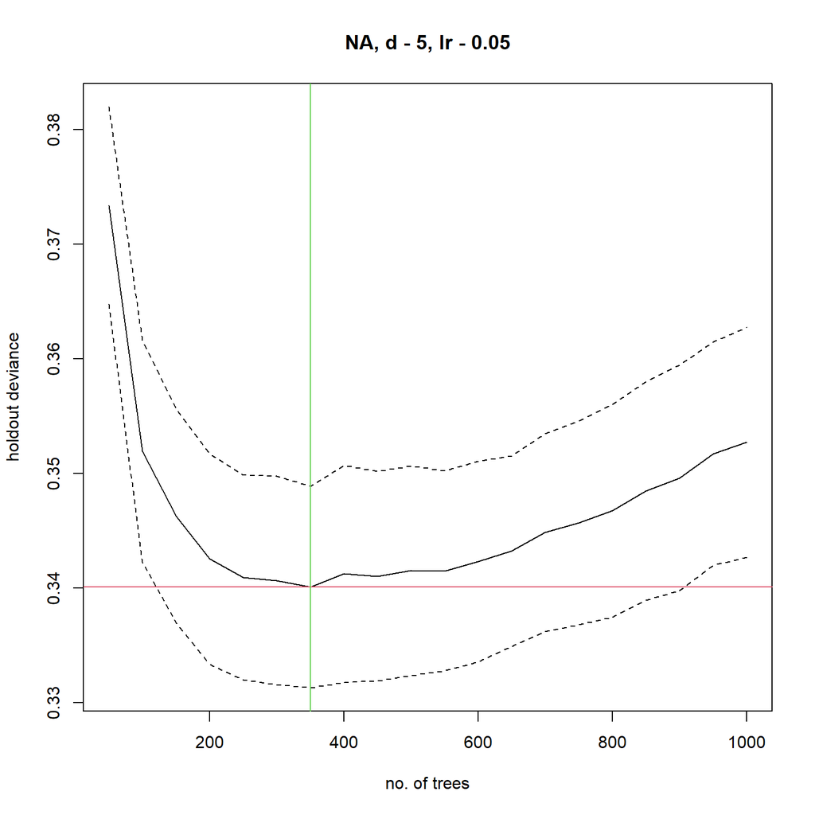

```
##
## mean total deviance = 0.609
## mean residual deviance = 0.239
##
## estimated cv deviance = 0.34 ; se = 0.009
##
## training data correlation = 0.784
## cv correlation =  0.631 ; se = 0.013
##
## training data AUC score = 0.969
## cv AUC score = 0.933 ; se = 0.006
##
## elapsed time -  0.02 minutes
```

```r
summary.gbm(brt.naive, plotit = F)
```

```
##                                                           var    rel.inf
## X2.3.alpha                                         X2.3.alpha 19.8675164
## X4.4.Ruggedness                               X4.4.Ruggedness 16.3533271
## X5.3b.WoodDemand2828                     X5.3b.WoodDemand2828 13.2798455
## X1.1.Accessibility                         X1.1.Accessibility  8.4833231
## X4.5.SolarRad                                   X4.5.SolarRad  7.7842919
## X5.2.ForestCover1850                     X5.2.ForestCover1850  7.5025515
## X0.3.ForestMSPA2                             X0.3.ForestMSPA2  5.9296761
## X3.1.ForestIncrement                     X3.1.ForestIncrement  5.7846235
## X3.4.CropSuitability                     X3.4.CropSuitability  4.3647457
## X6.4.Felling_PercentageAverage X6.4.Felling_PercentageAverage  3.7498581
## X0.1b.ForestCover                           X0.1b.ForestCover  3.5157090
## X3.2.Growing.Stock                         X3.2.Growing.Stock  1.3264050
## X2.1.GDD5                                           X2.1.GDD5  1.0713311
## X0.4.BiogeoRegions2016                 X0.4.BiogeoRegions2016  0.7110568
## X1.2a.PopDensityLandScan             X1.2a.PopDensityLandScan  0.2757390
```

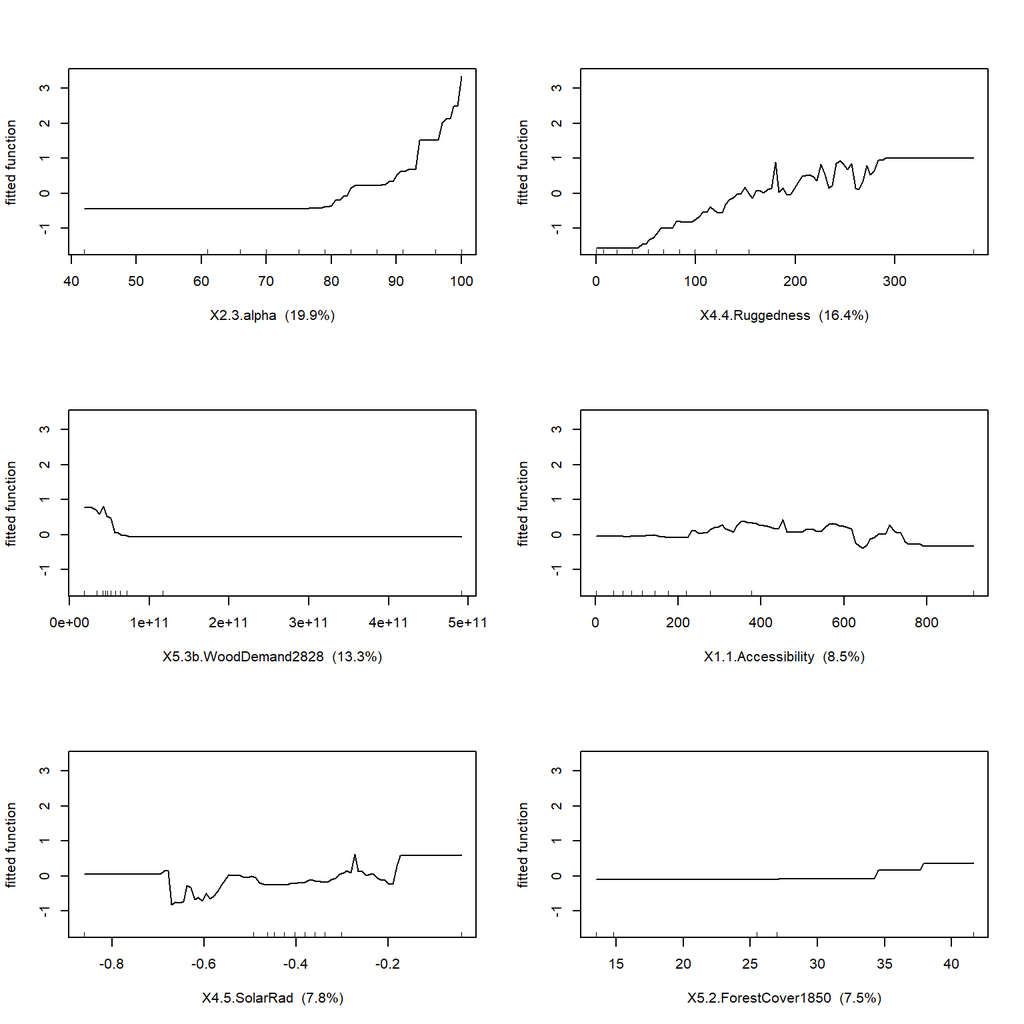

```r
gbm.plot(brt.naive, n.plots=6, plot.layout=c(3, 2), write.title = FALSE)
```

These graphs are called partial dependency plots, and show how the response variables varies as a function of one predictor at the time, when the other predictors are held constant at their respective means.

```r
# evaluate our model based on the test dataset.
(e <- dismo::evaluate(p = test.data %>%
                filter(Y.Primary.forest==1),
              a = test.data %>%
                filter(Y.Primary.forest==0),
              brt.naive,
              n.trees=brt.naive$gbm.call$best.trees))
```

```
## class          : ModelEvaluation
## n presences    : 138
## n absences     : 1388
## AUC            : 0.9255158
## cor            : 0.55779
## max TPR+TNR at : -2.899973
```

We have a very high Area Under the Curve, and a moderately high correlation.  
Compare these values with those of the brt self-statistics. Why are they lower?  
Never heard of AUC, TPR and TNR? check [here](https://en.wikipedia.org/wiki/Receiver_operating_characteristic%5D)

```r
## predict to the whole landscape
myp <- gbm::predict.gbm(brt.naive,
                           values(mystack[[-1]], na.rm=T) %>%
                             as.data.frame(),
                           type="response")
```

```
## Using 350 trees...
```

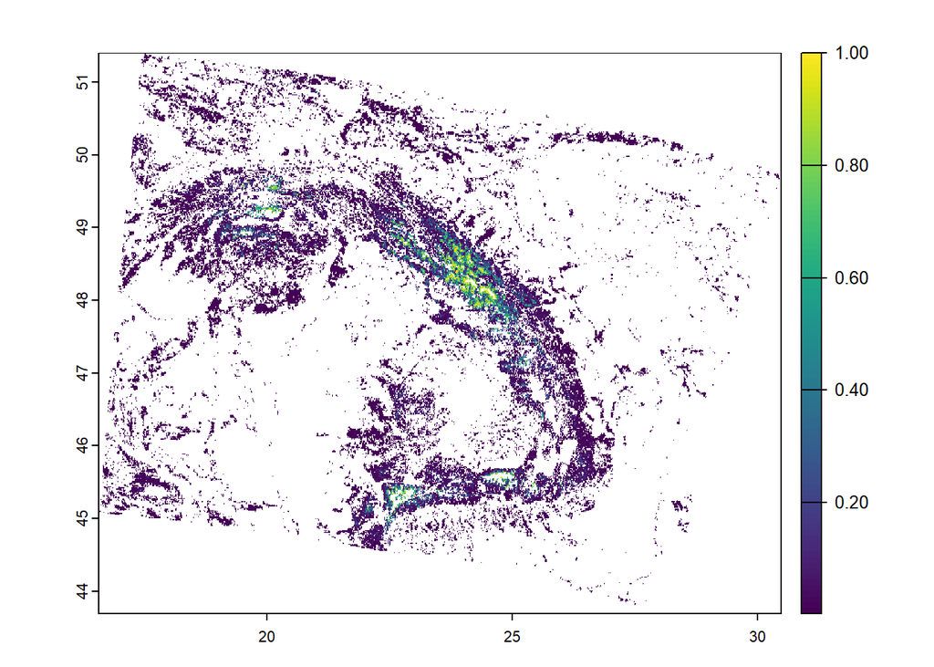

```r
myp.coords <- crds(mystack[[-1]], na.rm=T)


# Create a new raster using the original as a template, and replace non-na values with predictions based on their coordinates
myp.raster.naive <- mystack[[1]]
cell_indices <- cellFromXY(myp.raster.naive, myp.coords)
myp.raster.naive[cell_indices] <- myp

## mask non forest pixels
myp.raster.naive <- mask(myp.raster.naive, mask = mystack$X0.0b.mask)

plot(myp.raster.naive)
```

Build boxplots comparing the predicted values of primary vs. non-primary forests.

```r
mysample.naive$predicted <- gbm::predict.gbm(brt.naive, mysample.naive, type="response")
```

```
## Using 350 trees...
```

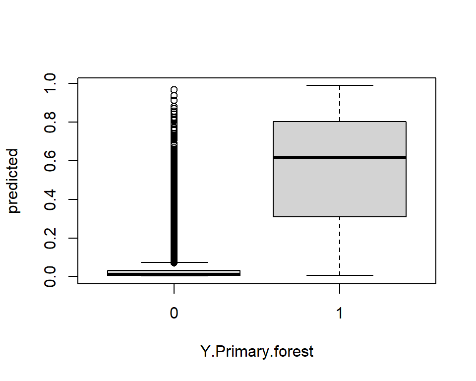

```r
boxplot(predicted ~ Y.Primary.forest, data=mysample.naive)
```

The results look good. Too good. This is because the model is severely overfitted. The problem mostly derives from the fact that presence data (primary forests) have a geographical distribution completely different from that of the background points. Being all environmental data autocorrelated (at least to a certain extent), the clustering in presence data means that even those presence points not used for training the model are on average very similar to the points used for training the model. This means that our cross-validation is overly optimistic because we are not respecting the assumption that train and test data are completely independent. A more honest evaluation of our model could be obtained dividing train and test data in blocks based on their geographical distribution.

### Spatially-aware model

To define the size of a spatial block, we first need to check for the spatial autocorrelation of predictors. We can do this using the package `blockCV`.

[output not shown]

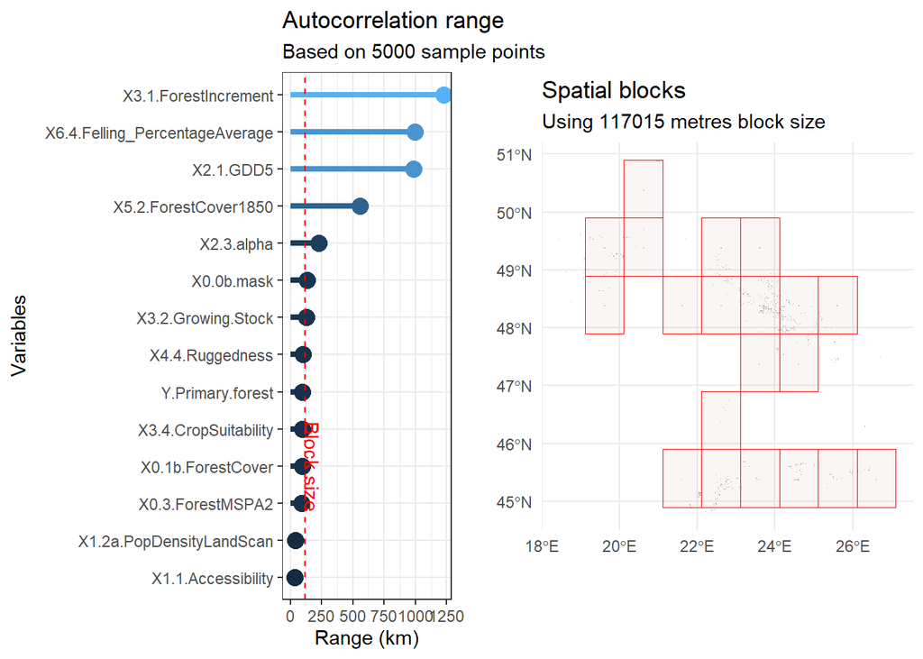

```r
library(blockCV)
library(automap)
library(cowplot)

# make mysample.naive a spatial 'sf' object
mysample.naive.sf <- mysample.naive %>%
  st_as_sf(coords=c("x","y"),
           crs=crs(mystack))

## Calculate spatial aucotorrelation of continuous predictors
## Takes quite long-time to run!
## suggest to skip and replace with
## autocorrelation.i <- 138000 #120 km
sac <- cv_spatial_autocor(r = mystack[[-c(5,14, 16)]],
                        column = "Y.Primary.forest",
                        num_sample = 5000,
                        plot = TRUE,
                        progress = T)
```

```r
autocorrelation.i <- sac$range
print(paste("Autocorrelation is", round(autocorrelation.i/1000), "km"))
```

```
## [1] "Autocorrelation is 117 km"
```

```r
#spatial blocking with randomly assigned grid cells,
sb2 <- cv_spatial(x = mysample.naive.sf,
                    column = "Y.Primary.forest",
                    r = mystack[[2]],
                    size=autocorrelation.i,
                    k = 5,
                    iteration=49,
                    selection = "random",
                    seed=100,
                    progress = T)
```

```
##   |                                                                              |                                                                      |   0%  |                                                                              |=                                                        …
##   train_0 train_1 test_0 test_1
## 1    5476     546   1459    147
## 2    5466     584   1469    109
## 3    5767     625   1168     68
## 4    5624     529   1311    164
## 5    5407     488   1528    205
```

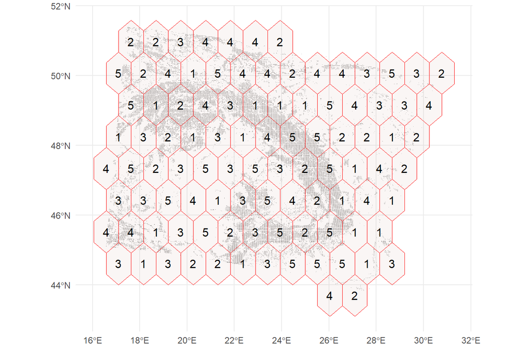

After splitting our data in train and test dataset, we can refit the model and obtain a more accurate validation.

```r
train.data.aware <- mysample.naive %>%
  filter(sb2$folds_ids != 5)
test.data.aware <- mysample.naive %>%
  filter(sb2$folds_ids == 5)


#### run BRTs and explore output
brt.aware <- gbm.step(data=train.data.aware,
                        gbm.x = 5:19, gbm.y = "Y.Primary.forest",
                        family = "bernoulli", tree.complexity = 5,
                        learning.rate = 0.05, bag.fraction = 0.5)
```

```
##
##
##  GBM STEP - version 2.9
##
## Performing cross-validation optimisation of a boosted regression tree model
## for NA and using a family of bernoulli
## Using 5895 observations and 15 predictors
## creating 10 initial models of 50 trees
##
##  folds are stratified by prevalence
## total mean deviance =  0.571
## tolerance is fixed at  6e-04
## ntrees resid. dev.
## 50    0.3543
## now adding trees...
## 100   0.3327
## 150   0.3279
## 200   0.3266
## 250   0.3263
## 300   0.3265
## 350   0.3276
## 400   0.3282
## 450   0.3278
## 500   0.3275
## 550   0.3275
## 600   0.3292
## 650   0.3297
## 700   0.3308
## 750   0.3315
## 800   0.3332
## 850   0.3349
## 900   0.3359
## 950   0.3363
## 1000   0.3384
```

```
## fitting final gbm model with a fixed number of 250 trees for NA
```

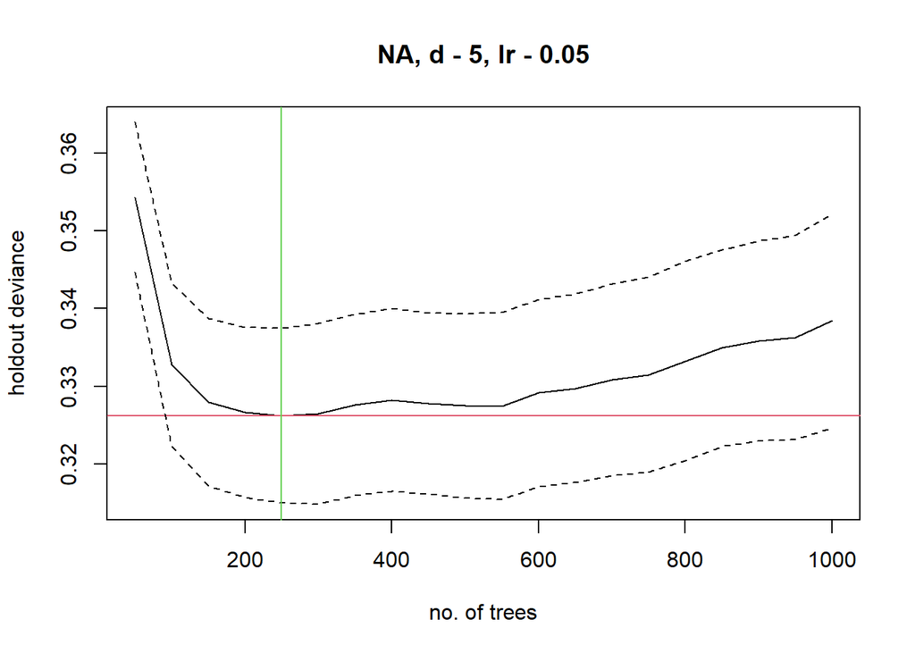

```
##
## mean total deviance = 0.571
## mean residual deviance = 0.241
##
## estimated cv deviance = 0.326 ; se = 0.011
##
## training data correlation = 0.756
## cv correlation =  0.61 ; se = 0.018
##
## training data AUC score = 0.964
## cv AUC score = 0.932 ; se = 0.006
##
## elapsed time -  0.03 minutes
```

```r
(e <- evaluate(test.data.aware %>%
                filter(Y.Primary.forest==1),
              test.data.aware %>%
                filter(Y.Primary.forest==0),
              brt.aware,
              n.trees=brt.aware$gbm.call$best.trees))
```

```
## class          : ModelEvaluation
## n presences    : 205
## n absences     : 1528
## AUC            : 0.9274263
## cor            : 0.5844027
## max TPR+TNR at : -1.90139
```

Notice how AUC and correlation changed, compared to the model test.statistics of the our naive model.

Congratulations!  
You have just fitted your (first?) BRT model. Actually we have just scratched the surface here, but this is a powerful technique for creating spatial distribution models based on a machine-learning algorithm.